# Crypto-devises

Habiba BOUAJLA, Kevin AUBRIET & Gabriel CURINGA

07/01/2019

# Présentation du groupe et du rôle de chacun

Notre groupe est composé de 3 membres : Habiba Bouajla, Gabriel Curinga et Kevin Aubriet. Dans un premier temps, nous ne nous sommes pas répartis les tâches mais avons préféré travailler tous ensemble sur la sélection des données ainsi que le traitement des dataframes pour pourvoir se familiariser avec le language R et s’entraider. Une fois tout le monde à l’aise avec la gestion des données avec R, nous nous sommes répartis les tâches de cette manière :

- Habiba s’est occupée du test de correlation du Bitcoin avec les autres crypto-monnaies qui comprend un script de test de correlation ainsi que 3 matrices.
- Gabriel, lui, a généré des graphiques du cours du Bitcoin (un avec une seule courbe et un autre avec plusieurs courbes pour chaque année), un graphique de variation du Bitcoin pour voir les différentes hausses ou baisses du bitcoin.
- Kevin devait réaliser les scripts de calcul du cours du Bitcoin comprenant le calcul des moyennes, variances et écarts-types de différentes données, de faire deux graphiques : un diagramme circulaire pour analyser le marketCap du Bitcoin par rapport aux autres crypto-monnnaies et un graphique avec plusieurs courbes pour chaque crypto-monnaie.

Le rapport et le support de présentation orale ont été faits par tous les membres de l’équipe.

# Descriptif du sujet et de ses finalités

Depuis plusieurs années, le phénomène de la crypto-monnaie prend de plus en plus de place dans nos mondes bancaires et financiers. Il s’agit d’une monnaie virtuelle et cryptée, c’est-à-dire qu’elle n’est utilisable que par une personne possédant le code permettant de décrypter la monnaie. Comparées aux monnaies ordinaires, les cryptomonnaies sont gérées par un grand livre de comptes ouvert et consultable par tous (la blockchain) qui répertorie l’ensemble des transactions depuis l’origine. Ainsi, nous voudrons faire quelques considérations en exploitant les données qui nous sont mises à disposition par la blockchain.

L’objectif de notre projet est d’utiliser les données des cours des crypto-devises de 2015, 2016 et 2017. Cela a pour but de calculer la moyenne et la variance d’un certain nombre de variables comme le cours du Bitcoin, la valeur des transactions et la part de marché par crypto-monnaies. Nous avons également effectué un test de corrélation pour vérifier si les autres crypto-devises sont ou pas corrélées au Bitcoin.

# Méthodologie suivie pour répondre aux questions

Pour mener à bien notre projet et répondre le plus précisement possible aux objectifs, nous avons tout d’abord rechercher les données relatives aux crypto-monnaies les mieux adaptées. La qualité des données récoltées est primordiale dans un tel exercice où nous souhaitons effectuer des vérifications d’hypothèses et des tests de corrélations.

### Environnement de travail

C’est alors que le groupe a démarré un projet dans le langage R dans lequel nous avons mis en place un environnement de travail qui suit l’architecture suivante :

- PRE = scripts d’imports et de traitements des données
- FIG = scripts de créations des graphiques
- R = scripts de vérifications d’hypothèses et des tests de corrélations
- REP = dossier contenant le rapport
- data = dossier contenant les données exploitées dans ce projet

Tout ce projet se trouve sur un git (hebergé sur GitHub) pour faciliter le travail en groupe évidemment.

### Traitements de données et graphiques

Une fois que l’environnement a été mis en place, nous avons effectué tous les traitements de données/tableaux pour en tirer uniquement les choses utiles.

La première chose que nous avons fait est de poser l’hypothèse que la baisse ou la hausse du cours du Bitcoin était favorisée durant différentes périodes sur ces 3 dernières années. C’est alors que nous avons réalisé deux graphiques sur l’évolution du cours Bitcoin de 2015 à 2018 : l’un croisant les courbes des différentes années suivant les mois, et l’autre où les données sont présentes sur une mêmes courbe suivant les mois également.

Par la suite, nous avons voulu approfondir la vérification de l’hyothèse en réalisant un graphique des variations du cours du Bitcoin en pourcentage (%) d’un jour sur l’autre pendant l’année 2016 et 2017.

Il nous a été demandé de calculer les moyennes et variances de différentes variables sur les années 2016 et 2017 :

- cours minimal du Bitcoin
- cours maxiaml du Bitcoin
- valeur des transactions
- proportions des transactions en Bitcoin par rapport aux autres crytpo-devises

Nous avons effectivement réalisé ces calculs, cependant nous avons remarqué que les résultats des variances n’ont pas été satisfaisants. C’est pourquoi nous avons décidé de calculer les écart-types de ces variables car l’écart-type est plus parlant ; il correspond à l’échelle de nos données.

Enfin, nous avons terminé par un test de corrélation comme demandé pour vérifier si les autres crytpo-devises sont ou pas corrélées au Bitcoin. Pour ce faire, nous avons utilisé un “Corrélogramme” qui produit une matrice de corrélation entre toutes les crypto-monnaies. La matrice montre le lien de -1 (corrélation négative) à 1 (corrélation positive), en passant par 0 (pas de corrélation) entre deux monnaies.

# Données utilisées

Premièrement, nous avons recherché des données sur l’évolution du cours du Bitcoin depuis ces dernières années. En suite, il était important de faire coïncider ces données avec l’évolution du cours des autres crypto-monnaies majeures : Etherum, Litecoin, Dash, Monero, Ripple, Nem. Finalement, nous sommes parvenus à trouver des fichiers au format CSV (facilement exploitable) qui contiennent la quasi totalité des données que nous recherchions de 2013 à 2018 pour chaque monnaie.

### Sources des données

La récolte de données s’est faite sur des sites plutôt réputés, ou du moins dont on est sûrs de la véracité de celles-ci.

- data.gouv.fr
- [kaggle.com](https://www.kaggle.com/dbarkhorn/crypto-correlation/data)

### Données récoltées

- En dollars
  - Prix du premier achat du jour (Open)
  - Prix du dernier achat du jour (Close)
  - Prix le plus bas du jour (Low)
  - Prix le plus haut du jour (High)
- La valeur de toutes les unités de la crypto-monnaie échangées dans la journée (Volume)
- La valeur de toutes les unités de la crypto-monnaie sur le marché (Market.Cap)
- Variations d’un jour à l’autre du cours du Bitcoin en %

### Traitement des données

Les données que nous avons récupéré ne correspondaient pas parfaitement à un traitement convenable. C’est pourquoi nous avons décidé de les formater.

Nous avons effectué des fonctions de récupération de chaque élément d’une date (jour, mois et année) dans le but de nous faciliter la tâche dans l’exploitation des données et surtout dans la création de graphique.

```r
##Extraction de l'année
getYear <- function(str) {
  res <- str_split(str, ", ")[[1]][[length(str_split(str, ", ")[[1]])]]
  return(res)
}
##Extraction du mois
getMonth <- function(str){
  res <- str_split(str, ", ")[[1]][1]
  res <- str_split(res, " ")[[1]][1]
  return(res)
}
##Extraction du jour
getDay <- function(str){
  res <- str_split(str, ", ")[[1]][1]
  res <- str_split(res, " ")[[1]][2]
  return(res)
}
```

Souvent, nous avons dû traiter les données déjà présentes dans les fichiers CSV pour les formater de manières à ce qu’elles soient exploitables. Par exemple, ci-dessous nous avons dû créer une fonction qui retire le symbole “%”.

```r
getVariation <- function(str){
  res <- str_replace(str, "%", "")
  return(res)
}
```

La fonction getData prend en parametre la source d’un fichier csv.En effet, nous avons récupérer un groupe de fichier csv (comprenant chacun les données d’une crypto-monnaie) qui disposait de la même structure, nous avons donc fait une fonction pour pouvoir les traiter. La fonction va lire le csv, ensuite rajouter 3 colonnes pour faciliter le traitement de la date (la date du tableaux de données étaient inexploitables). Grace à tout cela, nous avons trier notre tableau pour garder que les données concernant les années passées 2015.

```r
getData2015 <-function(src){
  res <- read.csv(src)
  ##Ajout des colonnes jour, mois et année
  ##pour faciliter le traitement des données
  for (i in 1:nrow(res)) {
    res$Day[i] <- as.numeric(getDay(res$Date[i]))
    res$Month[i] <- match(getMonth(res$Date[i]), month.abb)
    res$Year[i] <- as.numeric(getYear(res$Date[i]))

    ##Creation d'une nouvelle colonne Date
    ##Du type date plus exploitable
    date <- paste(res$Year[i], res$Month[i], sep = "-", collapse=NULL)
    date <- paste(date, res$Day[i], sep = "-", collapse=NULL)
    res$DateFormat[i] <- format(as.Date(date))

  }
  ##on ne conserve que les données datant au minimum de 2015
  resF<-res[res$Year>=2015,]

  ##tri dans l'ordre des années puis des mois
  resF <- resF[order(month(resF$Day)),]
  resF <- resF[order(month(resF$Month)),]
  resF <- resF[order(month(resF$Year)),]

  return(resF)
}
```

# Résultats obtenus et visualisation graphique

> Hypothèse : L’évolution du cours du Bitcoin dépend de la période de l’année.

### Évolution du cours du bitcoin de 2015 à 2017

Tout d’abord nous avons voulu tracer la courbe de l’évolution du cours du bitcoin sur plusieurs années pour avoir une vue d’ensemble de l’augmentation de valeur de cette crypto-monnaie. Pour cela, nous avons en premier lieu eu à trier le tableaux dans l’ordre croissant des années afin d’avoir une courbe cohérente.

Nous remarquons dans la courbe générée que le cours du bitcoin est en augmentation constante de 2015 jusqu’en 2017. Le cours du bitcoin subit durant l’année 2017 une évolution exponentielle, le prix d’un bitcoin frôle les 20 000 $, après ce pic, son cours chute durant l’année pour osciller autour des 10 000 $.

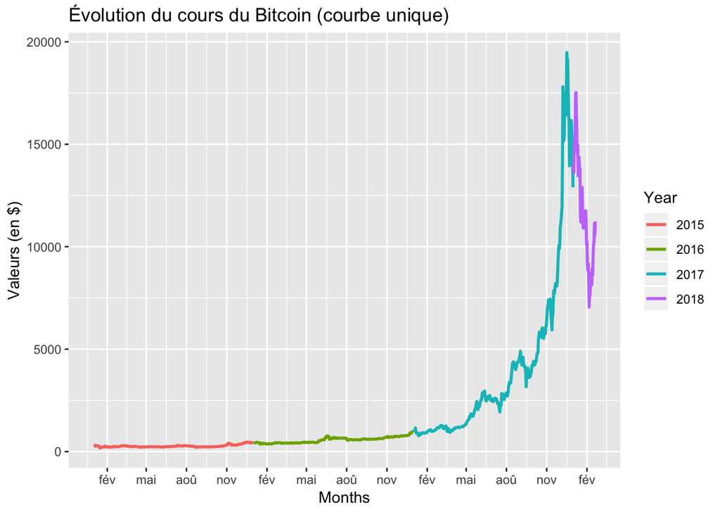

```r
ggplot(bitcoin_price_sorted, aes(x=as.Date(DateFormat), y=Open, color=Year, group=Year)) +
  ggtitle("Évolution du cours du Bitcoin (courbe unique)")+
  ylab("Valeurs (en $)")+
  scale_x_date(name="Months", labels = date_format("%b"), breaks = "3 month")+
  geom_line(aes(colour=Year), size=1)
```

Afin d’y voir plus clair et de poser une hypothèse sur les variations du cours du bitcoin, nous avons fait le choix de diviser cette courbe en trois courbes représentant chaque année. Nous pourrons donc analyser les variations du bitcoin en fonction de la période de l’année et donc comparer le cours des différentes années en fonction des mois car elles seront superposées. En analysant cette courbe nous remarquons que les années de 2015 et 2016 du bitcoin subissent les même variations tandis que celle de 2017 en a des beaucoup plus marquées. Si l’on regarde bien les variations, on remarque que milieu janvier le court du bitcoin subit une légère baisse de sa valeur peu importe l’année, ce phénomène se produit aussi durant le mois d’août pour toutes les années. Début novembre, une augmenation soudaine du cours est à déplorer pour les années 2015 et 2016. Ses petits pics de variations montrent bien que certaine période de l’année sont plus propices à la baisse ou à la hausse de la valeur du bitcoin, la période de l’année influe donc bien le cours du bitcoin.

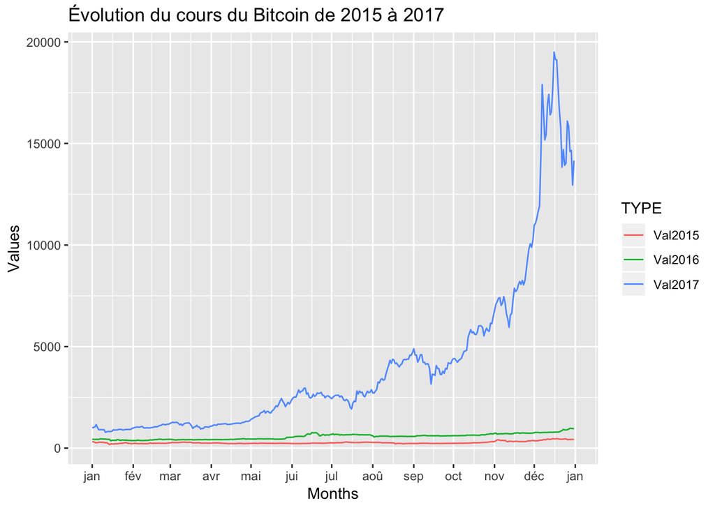

```r
resultats <- data.frame(Val2015= bitcoin_price_sorted2015$Close, Val2016=bitcoin_price_sorted2016$Close, Val2017=bitcoin_price_sorted2017$Close, Moi=bitcoin_price_sorted2015$Month ,Jour=bitcoin_price_sorted2015$DateFormat)

prediction2 <- gather(
  data = resultats,
  key = TYPE,
  value = VAL,
  Val2015,Val2016, Val2017
)

ggplot(
  prediction2,
  aes(x = as.Date(Jour), y = VAL, color = TYPE),)+
  ggtitle("Évolution du cours du Bitcoin de 2015 à 2017")+
  ylab("Values")+
  scale_x_date(name="Months", labels = date_format("%b"), breaks = "1 month")+
  geom_line()
```

### Variations du cours du Bitcoin en 2016 et 2017

Pour renforcer notre hypothèse nous avons tenu à verifier par d’autres données nos propos. Pour cela nous sommes aller chercher un jeu de données qui correspondait aux variations du bitcoin d’un jour à l’autre. Nous avons donc trouver un fichier csv qui nous exprime en pourcentage la variation du bitcoin d’un jour à un autre.

Nous pouvons voir que ce graphique vient appuyer notre hypothèse puisque mi-janvier comme remarqué sur la précédante courbe, le courbe chute ce qui se traduit par une variation négative en pourcentage du bitcoin, cette diminution du cours s’observe sur les deux années au même moment.

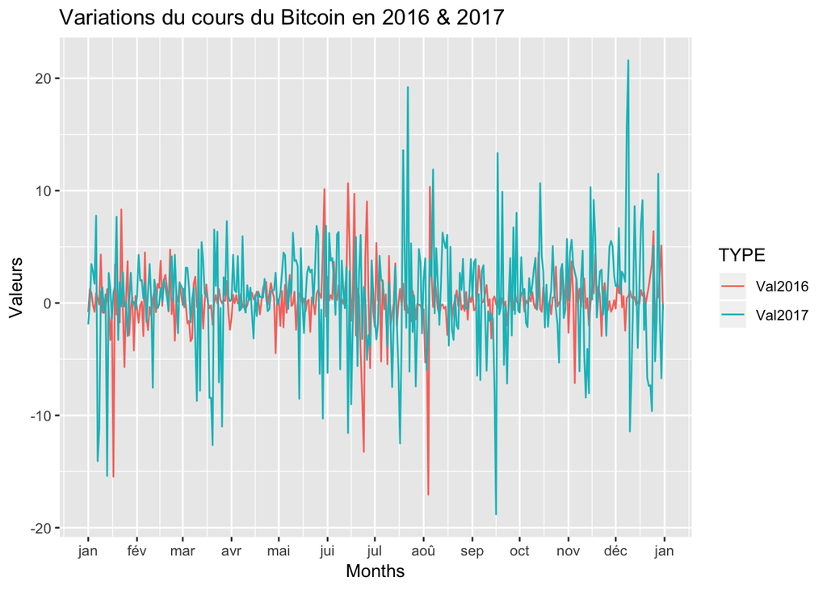

```r
## Création d'un nouveau data frame
## Plus exploitable
df <- data.frame(Val2016 = variationBtc_sorted_2016$Variation,
                 Val2017 = variationBtc_sorted_2017$Variation,
                 Month=variationBtc_sorted_2016$Month,
                 Date=variationBtc_sorted_2016$Date)

datas <- gather(
  data = df,
  key = TYPE,
  value = VAL,
  Val2016, Val2017
)

## Variations du cours du bitcoin en 2016 & 2017
## En %

ggplot(
  datas,
  aes(x = as.Date(Date), y = VAL, color = TYPE),)+
  ggtitle("Variations du cours du Bitcoin en 2016 & 2017")+
  ylab("Valeurs")+
  scale_x_date(name="Months", labels = date_format("%b"), breaks = "1 month")+
  geom_line()
```

> Hypothèse : On n’obtiendra pas les mêmes résultats finaux si l’on considère une fenêtre de temps plus grande pour calculer les moyennes.

### Moyennes et variances

L’objectif de cette partie est tout d’abord de calculer l’ensemble des moyennes et des variances sur les années 2015, 2016 et 2017. Pour alléger, nous ne montrerons que les tableaux de 2016 et 2017. À l’aide de ces résultats, nous voulons démontrer qu’on n’obtiendra pas les mêmes résultats finaux si l’on considère une fenêtre de temps plus grande pour calculer les moyennes.

Sur l’année 2016, nous pouvons remarquer qu’il n’y a pas beaucoup de variations suivant les mois, il y a une hausse linéaire sur toute l’année. On constate en toute logique, pour appuyer cette affirmation, que l’écart-type de chaque mois est plutôt peu élevé.

Moyennes, Variances & Écart-types du cours minimum sur l’année 2016

| Mois | Moyenne | Variance | EcartType | MoyenneAnnee |
| --- | --- | --- | --- | --- |
| Janvier | 418.8026 | 662.70233 | 25.743005 |  |
| Fevrier | 408.4224 | 633.68968 | 25.173194 |  |
| Mars | 420.0277 | 42.66477 | 6.531828 |  |
| Avril | 436.7533 | 258.98211 | 16.092921 |  |
| Mai | 466.1297 | 997.48405 | 31.582971 |  |
| Juin | 657.8787 | 5381.40400 | 73.358053 |  |
| Juillet | 670.2755 | 182.14477 | 13.496102 |  |
| Août | 586.1665 | 132.85774 | 11.526393 |  |
| Septembre | 608.3480 | 135.29604 | 11.631683 |  |
| Octobre | 646.4458 | 987.50905 | 31.424657 |  |
| Novembre | 733.6700 | 306.95399 | 17.520103 |  |
| Décembre | 832.5045 | 5900.01305 | 76.811542 | 574.30237704918 |

Cependant, l’écart-type de chaque mois en 2017 est beaucoup plus élevé. Pour deux périodes équivalentes (Janvier 2016 & Janvier 2017) il est plus de 3 fois plus grand : c’est pourquoi il y a beaucoup de variations et l’augmentation de la moyenne est exponentielle. En effet, elle débute en janvier 2017 à 937.450 et termine en décembre à 16051.632.

Moyennes, Variances & Écart-types du cours minimum sur l’année 2017

| Mois | Moyenne | Variance | EcartType | MoyenneAnnee |
| --- | --- | --- | --- | --- |
| Janvier | 937.450 | 7268.267 | 85.25413 |  |
| Fevrier | 1073.504 | 4510.067 | 67.15703 |  |
| Mars | 1161.893 | 9804.212 | 99.01622 |  |
| Avril | 1216.303 | 3914.541 | 62.56630 |  |
| Mai | 1968.787 | 121501.885 | 348.57121 |  |
| Juin | 2712.256 | 24209.897 | 155.59530 |  |
| Juillet | 2603.999 | 50188.766 | 224.02849 |  |
| Août | 3953.133 | 361224.394 | 601.01946 |  |
| Septembre | 4214.382 | 127584.023 | 357.18906 |  |
| Octobre | 5450.295 | 501722.727 | 708.32389 |  |
| Novembre | 8084.058 | 1454386.205 | 1205.97935 |  |
| Décembre | 16051.632 | 6425869.010 | 2534.92978 | 4144.68745205479 |

### Part de marché par crypto-monnaies

Le bitcoin est sans doute la crypto-monnaie qui a son marketcap le plus, haut autrement dit qui la capitalisation boursière (La capitalisation boursière correspond au prix qu’il faudrait payer s’il était possible de racheter toutes les actions) la plus élevée. Nous avons donc fait donc fait un diagramme de type camembert pour visualiser le pourcentage de chaque crypto-monnaie. On remarque donc que le bitcoin occupe plus de la moitié des parts du marché, l’ethereum arrive en deuxième place avec 26% et le ripple en troisième place.

```
## Les valeurs en % sont de : 53.50609 1.62463 26.02993 3.482204 1.408597 1.344368 12.60418
```

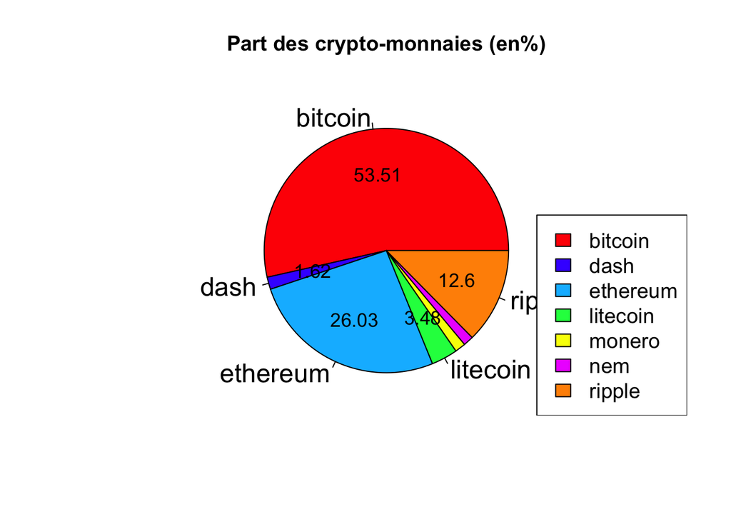

> Hypothèse : Le cours du bitcoin a une influence sur les autres cours de crypto-monnaies

### Tests de corrélations

Nous cherchons à vérifier l’intensité de la liaison qui peut exister entre les crypto-devises. Pour cela, nous avons effectué un test de corrélation pour vérifier si les autres crypto-devises ou pas corrélées au Bitcoin. Pour pouvoir effectuer le test de corrélation, nous avons dû, tout d’abord, récupérer les données pour les open, close et market de chaque crypto-monnaie. Ces données ont été récupérées par l’intermédiaire de notre script et enregistrées par la suite dans des csv correspondants. Après avoir regroupé nos fichiers csv, nous avons filtré les données selon le paramètre souhaité (open, close ou market cap). Notre étude s’effectue du 23/07/2017 au 20/02/2018. Pour cela, nous avons calculé le niveau de corrélation entre chaque paire de graphiques possibles. C’est ce que fait la fonction ci-dessous.

```r
#calcule de la matrice de corrélation
correlationTable <- function(graphs) {
  #matrice de corrélation
  cross <- matrix(nrow = length(graphs), ncol = length(graphs))
  for(graph1Id in 1:length(graphs)){
    graph1 <- graphs[[graph1Id]]
    print(graph1Id)
    for(graph2Id in 1:length(graphs)) {
      graph2 <- graphs[[graph2Id]]
      if(graph1Id == graph2Id){
        break;
      } else {
        correlation <- ccf(graph1, graph2, lag.max = 0)
        cross[graph1Id, graph2Id] <- correlation$acf[1]
      }
    }
  }
  cross
}
```

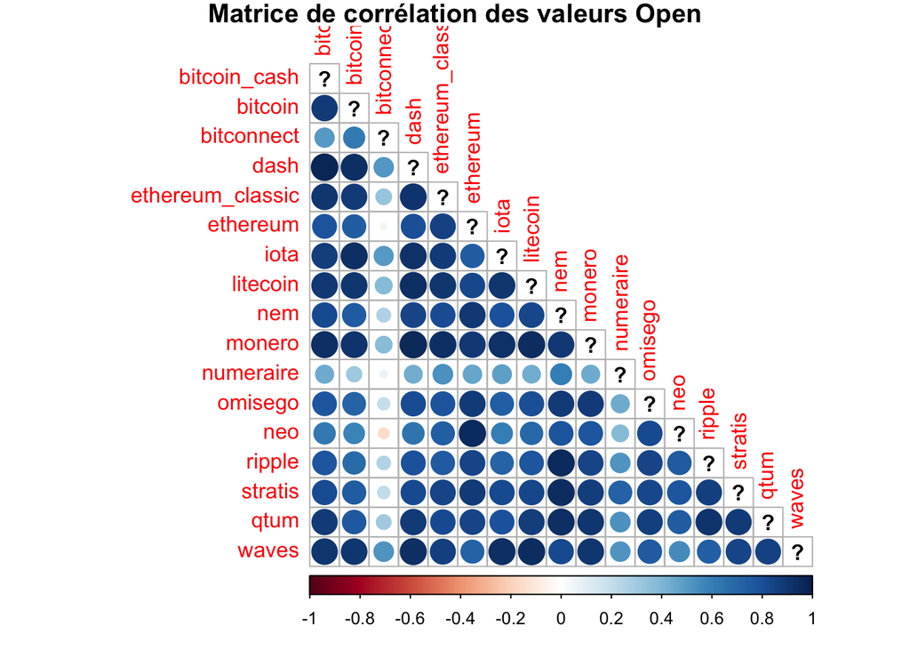

```r
#Corrélogramme : visualisation de la matrice de corrélation des Open
corrplot(corrO, title="Matrice de corrélation des valeurs Open", mar=c(0,0,1,0), type="lower")
```

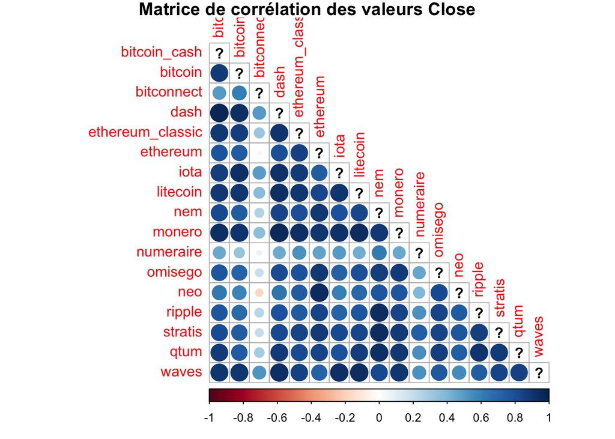

```r
#Corrélogramme : visualisation de la matrice de corrélation des Close
corrplot(corrC, title="Matrice de corrélation des valeurs Close", mar=c(0,0,1,0), type="lower")
```

Les deux matrices du dessus exprime la corrélation entre les valeurs Open et Close des crypto-monnaies, elles montrent une forte corrélation entre beaucoup de crypto-monnaies, en effet un rond bleu foncé indique que la corrélation entre les deux valeurs de deux monnaies se rapproche de 1, c’est à dire que les variations du cours des crypto-monnaies sont pratiquement les mêmes et interviennent en même temps.

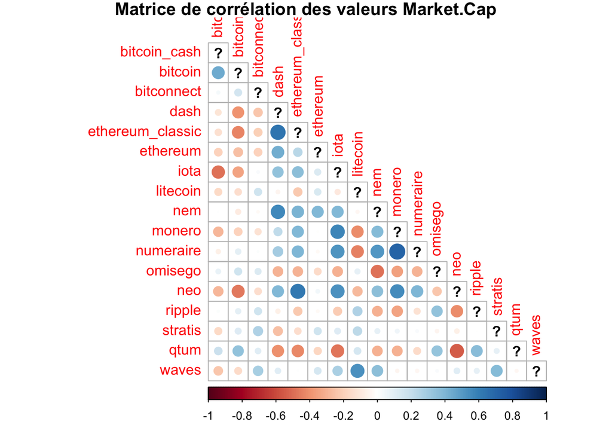

```r
#Corrélogramme : visualisation de la matrice de corrélation des Market.Cap
corrplot(corrM, title="Matrice de corrélation des valeurs Market.Cap", mar=c(0,0,1,0), type="lower")
```

La troisième matrice exprime la crorrélation entre les différentes crypto-monnaies sur la valeur MarketCap qui est la capitalisation boursière d’une monnaie. Si le rond est bleu entre deux monnaies, cela veut dire que lorsque la valeur total du marché d’une des deux monnaies augmente alors l’autre augmente aussi. Par contre fait tres intéressant, quand la corrélation est négative entre deux monnaies, cela veut dire que si la valeur total du marché d’une des deux monnaies augmente l’autre diminue. Ce phénomène peut etre expliquer par l’échange entre ces deux monnaies. Dans la matrice ci-dessus, prenons l’exemple de l’ethereum classic et du bitcoin, la corrélation entre ces deux monnaies est négative, on peut en déduire qu’un fort echange c’est fait entre ces deux monnaies ce qui aurait provoqué la diminution du total d’une et l’augmentation de l’autre.